# Instrumental Variables

ChatGPT 4o

2025-01-21

## 1 起源

工具变量法（Instrumental Variables, IV）起源于20世纪20年代，由Philip Wright在研究供给和需求模型中首次提出。IV方法旨在解决因果推断中的内生性问题，尤其是在存在反向因果关系或遗漏变量偏倚的情况下。20世纪中后期，IV逐渐在经济学、社会学、医学等领域中得到广泛应用，用于处理内生性问题并获得有效的因果估计。

## 2 原理

工具变量法的基本原理是通过引入一个工具变量（IV），来解决自变量与误差项相关的内生性问题。工具变量应满足两个关键条件：

1. **相关性条件**：工具变量与内生自变量强相关，即工具变量能够解释内生自变量的变化。
2. **外生性条件**：工具变量与误差项不相关，即工具变量不直接影响因变量，且不会与遗漏变量有关系。

通过工具变量，IV方法可以消除因变量与误差项之间的相关性，从而减少估计偏倚。具体来说，工具变量法通常分为两步：

- **第一步**：使用工具变量对内生自变量进行回归，获得预测值。
- **第二步**：将预测值作为自变量，对因变量进行回归，估计因果效应。

常见的IV估计方法包括两阶段最小二乘法（Two-Stage Least Squares, 2SLS）。其数学表达式为：

1. 第一阶段：

   $$X = \alpha + \pi Z + \epsilon$$

   其中，$X$ 为内生自变量，$Z$ 为工具变量，$\pi$ 为工具变量对内生自变量的影响系数。
2. 第二阶段：

   $$Y = \beta + \delta \hat{X} + \eta$$

   其中，$\hat{X}$ 为第一阶段回归的预测值，$\delta$ 为因果效应的估计值。

## 3 适用范围

工具变量法适用于以下情况：

- **内生性问题**：当自变量与误差项存在相关性时，普通最小二乘法（OLS）无法得到有效的因果估计，工具变量法可以解决此类内生性问题。
- **反向因果关系**：当存在反向因果关系（因变量对自变量产生影响）时，IV方法可以帮助识别因果方向。
- **遗漏变量偏倚**：当模型中存在无法观测的遗漏变量，并且遗漏变量同时影响自变量和因变量时，IV方法可以减少偏倚。

## 4 应用情境

工具变量法在多个领域中有广泛的应用，例如：

- **经济学**：用于解决教育对收入影响的内生性问题，找到合适的工具变量（如距离学校的远近）来进行估计。
- **公共政策评估**：用于评估政策干预的因果效应，例如通过区域特定政策作为工具变量来评估政策的经济影响。
- **医学研究**：用于评估治疗方法对健康结果的因果效应，例如通过随机化实验的分组作为工具变量来消除潜在的偏倚。
- **社会科学**：用于分析家庭结构、工作时间等对幸福感、健康等的影响，解决可能的反向因果问题。

## 5 优缺点

### 优点

- **解决内生性问题**：IV方法能够有效解决内生性问题，从而得到更可靠的因果效应估计。
- **广泛的适用性**：适用于多种情况，包括反向因果、遗漏变量等问题，在经济学、社会学、医学等领域应用广泛。
- **减少偏倚**：通过引入工具变量，可以减少由于遗漏变量或内生性引起的估计偏倚。

### 缺点

- **工具变量选择困难**：找到合适的工具变量是一个巨大的挑战，工具变量需要满足相关性和外生性条件，这在实践中很难验证。
- **弱工具变量问题**：如果工具变量与内生自变量的相关性较弱，IV估计会存在较大的标准误，导致估计不精确。
- **假设条件较强**：IV方法的有效性依赖于工具变量满足相关性和外生性假设，如果这些假设不成立，估计结果会受到偏倚。

## 6 在R中的实现及结果解释

在R中，可以使用`AER`包中的`ivreg()`函数来实现工具变量回归，以下是一个实现工具变量回归的示例：

```r
# 加载必要的包
library(AER)
# 示例数据：生成假设的数据集
set.seed(123)
data <- data.frame(
  education = rnorm(100, mean = 12, sd = 2),
  income = rnorm(100, mean = 50000, sd = 10000),
  distance_to_school = rnorm(100, mean = 5, sd = 2),
  age = rnorm(100, mean = 40, sd = 10)
)

# 构造内生变量和工具变量
# 以教育年限为内生变量，学校距离为工具变量，收入为因变量
iv_model <- ivreg(income ~ education + age | distance_to_school + age, data = data)

# 输出回归结果摘要
summary(iv_model)
```

```
##
## Call:
## ivreg(formula = income ~ education + age | distance_to_school +
##     age, data = data)
##
## Residuals:
##      Min       1Q   Median       3Q      Max
## -19243.1  -7325.5   -785.8   5792.5  30245.8
##
## Coefficients:
##             Estimate Std. Error t value Pr(>|t|)
## (Intercept) 63720.94   52214.86   1.220    0.225
## education   -1314.38    4169.32  -0.315    0.753
## age            30.62     101.48   0.302    0.763
##
## Residual standard error: 9943 on 97 degrees of freedom
## Multiple R-Squared: -0.03591,    Adjusted R-squared: -0.05727
## Wald test: 0.1396 on 2 and 97 DF,  p-value: 0.8698
```

```r
str(iv_model)
```

[output not shown]

[output cut: 26 more lines]

[output not shown]

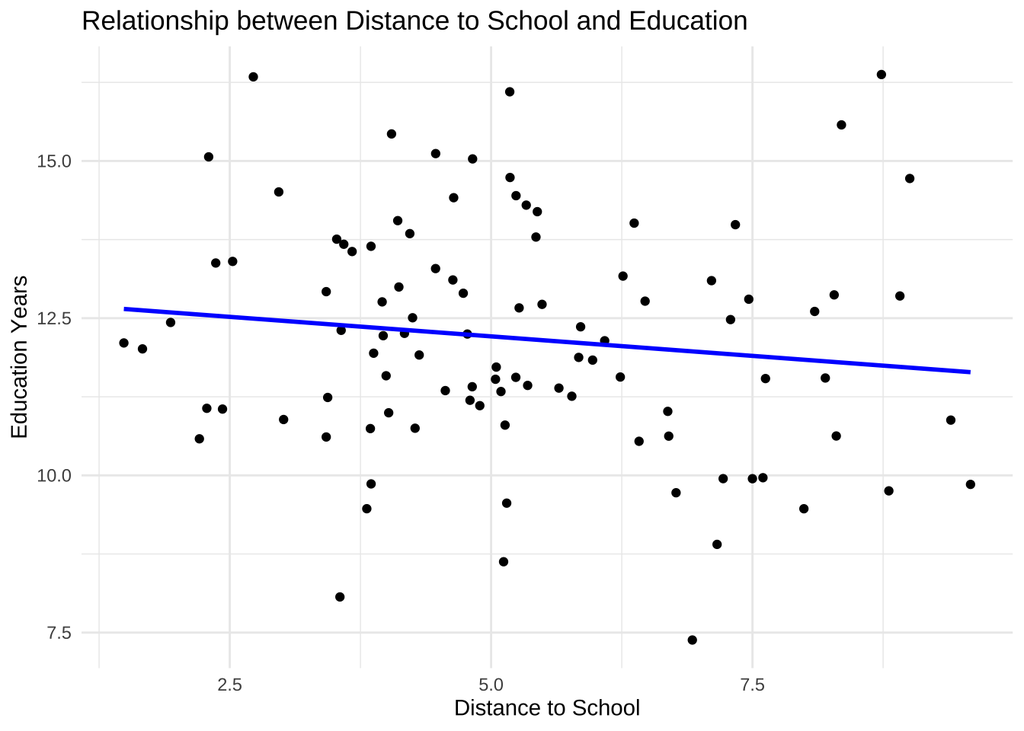

```r
# 可视化：绘制工具变量的散点图和拟合线
library(ggplot2)
ggplot(data, aes(x = distance_to_school, y = education)) +
  geom_point() +
  geom_smooth(method = "lm", se = FALSE, color = "blue") +
  labs(title = "Relationship between Distance to School and Education", x = "Distance to School", y = "Education Years") +
  theme_minimal()
```

### 结果的可视化

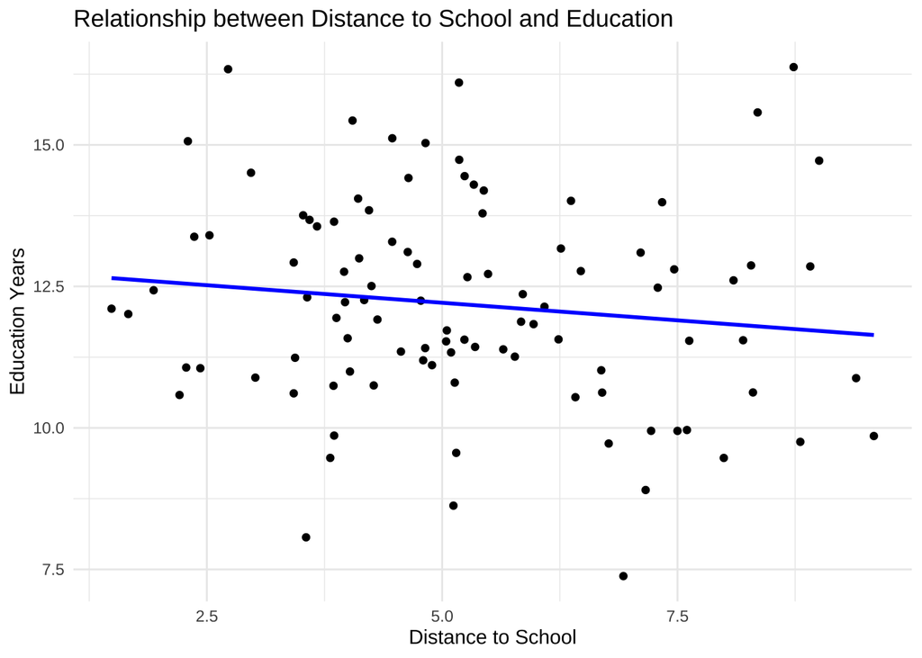

```r
# 使用ggplot2包绘制工具变量和内生自变量的关系图
ggplot(data, aes(x = distance_to_school, y = education)) +
  geom_point() +
  geom_smooth(method = "lm", se = FALSE, color = "blue") +
  labs(title = "Relationship between Distance to School and Education", x = "Distance to School", y = "Education Years") +
  theme_minimal()
```

## 7 小结

- 工具变量法（IV）是一种解决内生性问题的因果推断方法，适用于反向因果、遗漏变量等情境。
- 通过引入工具变量，IV方法能够有效减少偏倚，获得更可靠的因果效应估计。
- IV方法具有解决内生性问题和减少偏倚的优点，但面临工具变量选择困难和弱工具变量问题。
- 可以通过R中的`ivreg()`函数实现工具变量回归，并结合可视化工具展示工具变量与内生自变量之间的关系。